# Principal Component Analysis in R

### Constructing a PCA

Loading data, selecting columns to include in PCA and running a scaled and centred PCA.

```r
Env_18 <- read.csv("Env_18.csv")

colnames(Env_18)[1] <- "Param"

for(i in 1:18){
rownames(Env_18)[i] <- as.character(droplevels(Env_18$Param[i]))
}

Env_18 <- Env_18[,-1]


#str(Env_18)


Env.18.pca <- prcomp(Env_18, center = TRUE, scale. = TRUE)

#summary(Env.18.pca)

#str(Env.18.pca)

#Transposing the data so we are looking at correlation between the soil characteristics themselves and not correleations among the sites.
T.18 <- as.data.frame(t(Env_18))
T.18.pca <- prcomp(T.18, center = TRUE, scale. = TRUE)
#summary(T.18.pca)
```

- the centre, scaling, standard deviation of each principal component.

```r
$center, $scale, $sdev
```

- The relationship (correlation or anticorrelation, etc) between the initial variables and the principal components

```r
$rotation
```

- The values of each sample in terms of the principal components

```r
$x
```

### Theory Behind PCA Results

This code will calculate the PCA results for variables (i.e. columns): coordinates, cos2, and contributions

- var.coord = loadings * the component standard deviations
- var.cos2 = var.coord^2
- var.contrib. The contribution of a variable to a given principal component is (in percentage) : (var.cos2 * 100) / (total cos2 of the component)

```r
#helper function

var_coord_func <- function(loadings, comp.sdev){
  loadings*comp.sdev
}

# Compute Coordinates

loadings <- T.18.pca$rotation
sdev <- T.18.pca$sdev
var.coord <- t(apply(loadings, MARGIN = 1, var_coord_func, sdev))
head(var.coord[, 1:4])
```

```
                PC1        PC2         PC3         PC4
m_gv      0.1112659 -0.8397329 -0.27438780 -0.02808150
m_pH_H2O -0.3770343  0.3365268 -0.78532581 -0.02319610
m_pH_Ca  -0.3978461  0.1885975 -0.73551774 -0.08737664
m_CN      0.1787622 -0.6555604  0.60132147  0.15584940
m_Cl     -0.4319542 -0.3695436 -0.07478097  0.57131811
m_NO3     0.2612686 -0.5962655 -0.49718902 -0.44795962
```

```r
#compute Cos2 (the variable components squared), or quality of representation on given dimension
var.cos2 <- var.coord^2
head(var.cos2[, 1:4])
```

```
                PC1        PC2         PC3          PC4
m_gv     0.01238009 0.70515135 0.075288662 0.0007885708
m_pH_H2O 0.14215486 0.11325025 0.616736633 0.0005380592
m_pH_Ca  0.15828153 0.03556902 0.540986346 0.0076346773
m_CN     0.03195592 0.42975950 0.361587515 0.0242890340
m_Cl     0.18658447 0.13656246 0.005592193 0.3264043823
m_NO3    0.06826130 0.35553253 0.247196926 0.2006678208
```

```r
#Compute contributions
comp.cos2 <- apply(var.cos2, MARGIN = 2, FUN = sum)
contrib <- function(var.cos2, comp.cos2){var.cos2*100/comp.cos2}
var.contrib <- t(apply(var.cos2, MARGIN = 1, contrib, comp.cos2))
head(var.contrib[, 1:4])
```

```
               PC1        PC2        PC3         PC4
m_gv     0.2028662 17.8681349  2.2542900  0.06399317
m_pH_H2O 2.3294185  2.8696972 18.4663026  0.04366394
m_pH_Ca  2.5936781  0.9012987 16.1981906  0.61956032
m_CN     0.5236453 10.8898617 10.8266383  1.97107503
m_Cl     3.0574637  3.4604153  0.1674412 26.48798338
m_NO3    1.1185629  9.0089924  7.4015601 16.28435827
```

This code will calculate PCA results for individuals (i.e. rows)

- ind.coord = res.pca$x
- Cos2 of individuals. Two steps:
  - Calculate the square distance between each individual and the PCA center of gravity: d2 = [(var1_ind_i - mean_var1)/sd_var1]^2 + …+ [(var10_ind_i - mean_var10)/sd_var10]^2 + …+..
  - Calculate the cos2 as ind.coord^2/d2
- Contributions of individuals to the principal components: 100 * (1 / number_of_individuals)*(ind.coord^2 / comp_sdev^2). Note that the sum of all the contributions per column is 100

```r
# Coordinates of individuals
#::::::::::::::::::::::::::::::::::
ind.coord <- T.18.pca$x
head(ind.coord[, 1:4])
```

```
         PC1        PC2         PC3        PC4
aa  1.843619  0.6984034  1.39085931  0.8521719
ab  1.499047  3.3314063 -0.13836903 -0.4757199
ac  2.438382  2.3485011 -0.11155408 -1.0069934
ba -4.068176  0.4089068  0.67238375 -1.3135724
bb -4.251161  0.8734186  0.05115095 -0.9593515
bc -4.245708 -0.4283674  0.01116178 -0.5839797
```

```r
# Cos2 of individuals
#:::::::::::::::::::::::::::::::::
# 1. square of the distance between an individual and the
# PCA center of gravity
center <- T.18.pca$center
scale<- T.18.pca$scale
getdistance <- function(ind_row, center, scale){
  return(sum(((ind_row-center)/scale)^2))
  }
d2 <- apply(T.18,1,getdistance, center, scale)
# 2. Compute the cos2. The sum of each row is 1
cos2 <- function(ind.coord, d2){return(ind.coord^2/d2)}
ind.cos2 <- apply(ind.coord, 2, cos2, d2)
head(ind.cos2[, 1:4])
```

```
         PC1         PC2          PC3        PC4
aa 0.3221090 0.046224592 1.833272e-01 0.06882002
ab 0.1444967 0.713645955 1.231134e-03 0.01455225
ac 0.3631827 0.336901791 7.601385e-04 0.06194055
ba 0.8227422 0.008312142 2.247494e-02 0.08577727
bb 0.8706902 0.036753047 1.260538e-04 0.04434085
bc 0.9101629 0.009265135 6.290511e-06 0.01721926
```

```r
# Contributions of individuals
#:::::::::::::::::::::::::::::::
contrib <- function(ind.coord, comp.sdev, n.ind){
  100*(1/n.ind)*ind.coord^2/comp.sdev^2
}
ind.contrib <- t(apply(ind.coord, 1, contrib,
                       T.18.pca$sdev, nrow(ind.coord)))
head(ind.contrib[, 1:4])
```

```
         PC1        PC2          PC3      PC4
aa  3.094253  0.6866526 3.2179115510 3.273971
ab  2.045708 15.6235453 0.0318482443 1.020288
ac  5.412734  7.7643643 0.0207003940 4.571658
ba 15.066517  0.2353819 0.7520420308 7.779083
bb 16.452371  1.0739134 0.0043522633 4.149311
bc 16.410186  0.2583195 0.0002072405 1.537503
```

### PCA Visualisation

Now it’s time to plot the PCA.

we will first look at a package `ggbiplot`.

You will make a biplot, which includes both the position of each sample in terms of PC1 and PC2 and also will show you how the initial variables map onto this. You will use the `ggbiplot` package, which offers a user-friendly and pretty function to plot biplots. A biplot is a type of plot that will allow you to visualize how the samples relate to one another in our PCA (which samples are similar and which are different) and will simultaneously reveal how each variable contributes to each principal component.

```r
library(devtools)
install_github("vqv/ggbiplot")
```

```
Error: Failed to install 'ggbiplot' from GitHub:
  Could not resolve host: api.github.com
```

Many other packages exist for plotting PCAs. Another suite of packages are the `facto` package family, which again works off the `ggplot` functionality

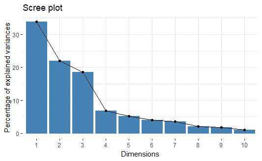

```r
library(factoextra)

#scree plot
fviz_eig(T.18.pca)
```

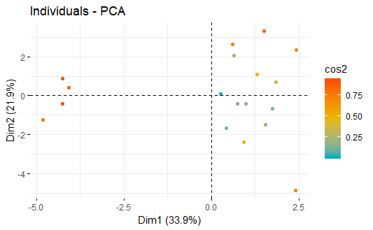

```r
#individuals (rows)
fviz_pca_ind(T.18.pca,
             col.ind = "cos2", # Color by the quality of representation
             gradient.cols = c("#00AFBB", "#E7B800", "#FC4E07"),
             repel = TRUE     # Avoid text overlapping
             )
```

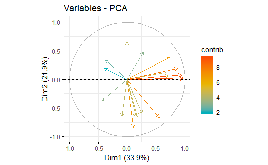

```r
#variables (columns)
fviz_pca_var(T.18.pca,
             col.var = "contrib", # Color by contributions to the PC
             gradient.cols = c("#00AFBB", "#E7B800", "#FC4E07"),
             repel = TRUE     # Avoid text overlapping
             )
```

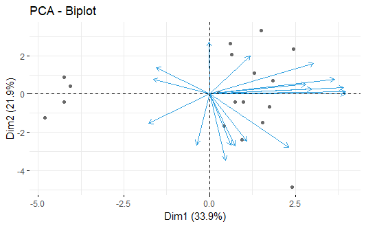

```r
#biplot
fviz_pca_biplot(T.18.pca, repel = TRUE,
                col.var = "#2E9FDF", # Variables color
                col.ind = "#696969"  # Individuals color
                )
```

```r
library(Factoshiny)

#result <- Factoshiny(T.18)
```

*Supplementary Variables*

Qualitative / categorical variables

Qualitative / categorical variables can be used to color individuals (rows) by groups. The grouping variable should be of same length as the number of active individuals

Code for extracting data from `Factoextra` package on PCA results

```r
library(factoextra)
# Eigenvalues
eig.val <- get_eigenvalue(T.18.pca)
eig.val
```

|  | eigenvalue | variance.percent | cumulative.variance.percent |
| --- | --- | --- | --- |
| Dim.1 | 6.102590e+00 | 3.390328e+01 | 33.90328 |
| Dim.2 | 3.946418e+00 | 2.192455e+01 | 55.82782 |
| Dim.3 | 3.339795e+00 | 1.855442e+01 | 74.38224 |
| Dim.4 | 1.232273e+00 | 6.845964e+00 | 81.22820 |
| Dim.5 | 9.323371e-01 | 5.179650e+00 | 86.40785 |
| Dim.6 | 7.314076e-01 | 4.063375e+00 | 90.47123 |
| Dim.7 | 6.372587e-01 | 3.540326e+00 | 94.01155 |
| Dim.8 | 3.753322e-01 | 2.085179e+00 | 96.09673 |
| Dim.9 | 3.178664e-01 | 1.765925e+00 | 97.86266 |
| Dim.10 | 1.847776e-01 | 1.026542e+00 | 98.88920 |

[output cut: 8 more lines]

```r
# Results for Variables (i.e. columns)
res.var <- get_pca_var(T.18.pca)
res.var$coord          # Coordinates
```

```
                Dim.1        Dim.2       Dim.3       Dim.4       Dim.5
m_gv      0.111265853 -0.839732903 -0.27438780 -0.02808150  0.14131077
m_pH_H2O -0.377034291  0.336526752 -0.78532581 -0.02319610  0.31017509
m_pH_Ca  -0.397846119  0.188597496 -0.73551774 -0.08737664  0.44118086
m_CN      0.178762201 -0.655560445  0.60132147  0.15584940  0.26621044
m_Cl     -0.431954241 -0.369543586 -0.07478097  0.57131811 -0.42964645
m_NO3     0.261268645 -0.596265483 -0.49718902 -0.44795962 -0.17330283
m_P      -0.093640083 -0.645165585 -0.48125006  0.39998612 -0.07197327
m_SO4     0.562335639 -0.674512882  0.29996960 -0.26640732 -0.06839073
m_oP      0.149484916 -0.650183708 -0.43463509 -0.35349059 -0.15274511
m_Ag      0.286071350  0.481619053  0.65068831 -0.09349290  0.05521270
m_N15    -0.004560037  0.658802210 -0.34964508 -0.21750290 -0.50196428
m_C13     0.723466186  0.063436438  0.19263045 -0.09810565  0.08771866
m_ell_L   0.950242328  0.079421097 -0.16582898  0.11348099  0.06337764
m_ell_T   0.965023047  0.028681649 -0.04672824  0.19253606  0.08631567
m_ell_K   0.961659184  0.006283594 -0.16389184  0.07798208  0.07916038
m_ell_F   0.680844645  0.124184473 -0.41158378  0.40877959  0.01851452
m_ell_R   0.735283923  0.385607360 -0.39666083  0.11863758 -0.10464491
m_ell_N   0.887223124  0.188047860 -0.12600716 -0.11469733 -0.10533169
               Dim.6       Dim.7        Dim.8       Dim.9       Dim.10
m_gv     -0.22075582 -0.24484726  0.067647672  0.23536813  0.075949897
m_pH_H2O -0.01072021  0.09762917  0.130195638  0.03103420  0.014920172
m_pH_Ca  -0.04159003  0.20969032  0.097379911 -0.05809716  0.044041212
m_CN     -0.10550025 -0.05459727  0.126427360  0.13572172  0.138809869
m_Cl     -0.07504961  0.27490413  0.246011161  0.03878089 -0.100371951
m_NO3     0.12181841  0.23500929  0.003365465 -0.01049143 -0.066309200
m_P       0.26640030  0.09908654 -0.044717318 -0.16464184  0.237872635
m_SO4    -0.06007044  0.20438634 -0.050011494 -0.09554164  0.019723689
m_oP      0.03871766 -0.35332325  0.199115010 -0.17979012 -0.062361649
m_Ag      0.26959407 -0.05728930  0.351728404 -0.17904768  0.095178641
m_N15    -0.27257853 -0.06437416 -0.034076681  0.03478598  0.242599995
m_C13    -0.53340625  0.29911645  0.131679971 -0.12833114  0.017001357
m_ell_L   0.13879603 -0.02282424 -0.057935436 -0.04137896  0.046652207
m_ell_T   0.02796525  0.02873647 -0.100542255 -0.01852263 -0.002357068
m_ell_K   0.09655992  0.06794289 -0.037205365  0.03914343 -0.058293695
m_ell_F  -0.24361689 -0.24972903 -0.073577909 -0.19679717 -0.062065535
m_ell_R   0.04487401 -0.13123913  0.246523101  0.17046922 -0.051047285
m_ell_N   0.22564433  0.17648596  0.020183919  0.22005097  0.044778122
               Dim.11      Dim.12        Dim.13        Dim.14        Dim.15
m_gv     -0.022071795 -0.05073337 -0.0928348941  0.0053493560 -0.0145811901
```

[output cut: 21 more lines]

```
m_CN     -1.308230e-02 -0.0016340627  1.481239e-17
m_Cl      9.638159e-04  0.0013384777  5.668727e-18
m_NO3    -2.616910e-03 -0.0008822547 -1.654855e-17
m_P       1.077928e-03 -0.0012824724 -7.889974e-18
m_SO4    -5.076396e-03  0.0007120342  1.324503e-17
m_oP      2.821966e-03 -0.0012298844  1.826477e-17
m_Ag      8.163222e-04  0.0008315561  2.743923e-18
m_N15    -4.421546e-03  0.0013646991  5.891328e-18
m_C13     4.550668e-03 -0.0021930436 -1.863395e-17
m_ell_L  -1.194905e-03  0.0019124089 -5.795160e-17
m_ell_T   3.206512e-02 -0.0034836135  1.882498e-17
m_ell_K  -2.576151e-02  0.0040528489  1.368053e-18
m_ell_F  -1.185272e-02 -0.0002074962  3.229532e-17
m_ell_R   4.365256e-03  0.0016625438 -2.374359e-17
m_ell_N   9.695369e-05 -0.0020015641  5.203761e-17
```

```r
res.var$contrib        # Contributions to the PCs
```

```
                Dim.1        Dim.2       Dim.3       Dim.4       Dim.5
m_gv     2.028662e-01 17.868134923  2.25428999  0.06399317  2.14179347
m_pH_H2O 2.329419e+00  2.869697177 18.46630255  0.04366394 10.31907760
m_pH_Ca  2.593678e+00  0.901298665 16.19819064  0.61956032 20.87662896
m_CN     5.236453e-01 10.889861704 10.82663830  1.97107503  7.60111368
m_Cl     3.057464e+00  3.460415268  0.16744122 26.48798338 19.79928540
m_NO3    1.118563e+00  9.008992411  7.40156005 16.28435827  3.22135328
m_P      1.436843e-01 10.547250674  6.93460604 12.98322994  0.55560936
m_SO4    5.181757e+00 11.528621447  2.69423008  5.75950581  0.50167391
m_oP     3.661681e-01 10.711962616  5.65626529 10.14024921  2.50242842
m_Ag     1.341018e+00  5.877656501 12.67728384  0.70933302  0.32696777
m_N15    3.407395e-04 10.997829374  3.66045468  3.83904353 27.02543371
m_C13    8.576741e+00  0.101970479  1.11104098  0.78105380  0.82529845
m_ell_L  1.479635e+01  0.159833806  0.82338137  1.04505508  0.43082325
m_ell_T  1.526023e+01  0.020845154  0.06537911  3.00827178  0.79910961
m_ell_K  1.515403e+01  0.001000491  0.80425700  0.49349482  0.67211382
m_ell_F  7.595946e+00  0.390779237  5.07220401 13.56036328  0.03676648
m_ell_R  8.859230e+00  3.767797125  4.71106226  1.14218776  1.17452771
m_ell_N  1.289887e+01  0.896052948  0.47541259  1.06757784  1.18999511
               Dim.6       Dim.7        Dim.8       Dim.9       Dim.10
m_gv      6.66292432  9.40751006  1.219242013 17.42812412  3.121800032
m_pH_H2O  0.01571257  1.49569631  4.516240631  0.30299569  0.120475398
m_pH_Ca   0.23649335  6.89987123  2.526521240  1.06185490  1.049709749
m_CN      1.52176467  0.46776327  4.258595059  5.79500782 10.427768866
m_Cl      0.77008282 11.85896388 16.124781133  0.47314134  5.452245909
m_NO3     2.02892693  8.66671027  0.003017688  0.03462777  2.379568910
m_P       9.70308784  1.54068381  0.532765024  8.52777545 30.622431739
m_SO4     0.49335792  6.55522991  0.666382939  2.87171103  0.210536316
m_oP      0.20495508 19.58973932 10.563119848 10.16920408  2.104679081
m_Ag      9.93713557  0.51502852 32.960902334 10.08539021  4.902636676
m_N15    10.15836581  0.65029043  0.309384673  0.38068333 31.851675512
m_C13    38.90063999 14.03992584  4.619805087  5.18106959  0.156429227
m_ell_L   2.63387172  0.08174796  0.894278458  0.53865976  1.177863866
m_ell_T   0.10692471  0.12958393  2.693279640  0.10793463  0.003006732
m_ell_K   1.27477734  0.72438960  0.368803764  0.48202893  1.839051459
m_ell_F   8.11437962  9.78638453  1.442378025 12.18408751  2.084739120
m_ell_R   0.27531529  2.70278124 16.191961101  9.14212731  1.410249686
m_ell_N   6.96128444  4.88769988  0.108541343 15.23357652  1.085131722
              Dim.11      Dim.12       Dim.13       Dim.14       Dim.15
m_gv      0.65674770  3.68704033 2.316298e+01  0.230457073  5.736887670
```

[output cut: 21 more lines]

```
m_CN     7.314158e+00  0.93080461  2.13390904
m_Cl     3.969943e-02  0.62451574  0.31253347
m_NO3    2.926670e-01  0.27133700  2.66345455
m_P      4.965646e-02  0.57334650  0.60544770
m_SO4    1.101304e+00  0.17673511  1.70620453
m_oP     3.403295e-01  0.52729015  3.24454425
m_Ag     2.847864e-02  0.24104836  0.07322666
m_N15    8.354958e-01  0.64922449  0.33756068
m_C13    8.850062e-01  1.67654657  3.37703251
m_ell_L  6.101872e-02  1.27491905 32.66301704
m_ell_T  4.394017e+01  4.23039589  3.44662963
m_ell_K  2.836212e+01  5.72587558  0.01820250
m_ell_F  6.003879e+00  0.01500864 10.14389629
m_ell_R  8.143581e-01  0.96353447  5.48300029
m_ell_N  4.017211e-04  1.39656157 26.33663149
```

```r
res.var$cos2           # Quality of representation
```

```
                Dim.1        Dim.2       Dim.3        Dim.4        Dim.5
m_gv     1.238009e-02 7.051513e-01 0.075288662 0.0007885708 0.0199687343
m_pH_H2O 1.421549e-01 1.132503e-01 0.616736633 0.0005380592 0.0962085850
m_pH_Ca  1.582815e-01 3.556902e-02 0.540986346 0.0076346773 0.1946405493
m_CN     3.195592e-02 4.297595e-01 0.361587515 0.0242890340 0.0708680001
m_Cl     1.865845e-01 1.365625e-01 0.005592193 0.3264043823 0.1845960760
m_NO3    6.826130e-02 3.555325e-01 0.247196926 0.2006678208 0.0300338705
m_P      8.768465e-03 4.162386e-01 0.231601619 0.1599888933 0.0051801520
m_SO4    3.162214e-01 4.549676e-01 0.089981759 0.0709728600 0.0046772918
m_oP     2.234574e-02 4.227389e-01 0.188907660 0.1249555971 0.0233310676
m_Ag     8.183682e-02 2.319569e-01 0.423395280 0.0087409223 0.0030484417
m_N15    2.079393e-05 4.340204e-01 0.122251679 0.0473075135 0.2519681348
m_C13    5.234033e-01 4.024182e-03 0.037106490 0.0096247185 0.0076945633
m_ell_L  9.029605e-01 6.307711e-03 0.027499249 0.0128779361 0.0040167249
m_ell_T  9.312695e-01 8.226370e-04 0.002183528 0.0370701340 0.0074503951
m_ell_K  9.247884e-01 3.948355e-05 0.026860534 0.0060812055 0.0062663663
m_ell_F  4.635494e-01 1.542178e-02 0.169401211 0.1671007542 0.0003427875
m_ell_R  5.406424e-01 1.486930e-01 0.157339817 0.0140748764 0.0109505572
m_ell_N  7.871649e-01 3.536200e-02 0.015877805 0.0131554781 0.0110947654
                Dim.6        Dim.7        Dim.8        Dim.9       Dim.10
m_gv     0.0487331335 0.0599501784 4.576208e-03 0.0553981579 5.768387e-03
m_pH_H2O 0.0001149230 0.0095314552 1.695090e-02 0.0009631216 2.226115e-04
m_pH_Ca  0.0017297303 0.0439700312 9.482847e-03 0.0033752804 1.939628e-03
m_CN     0.0111303021 0.0029808622 1.598388e-02 0.0184203851 1.926818e-02
m_Cl     0.0056324441 0.0755722816 6.052149e-02 0.0015039575 1.007453e-02
m_NO3    0.0148397253 0.0552293671 1.132635e-05 0.0001100701 4.396910e-03
m_P      0.0709691200 0.0098181420 1.999639e-03 0.0271069363 5.658339e-02
m_SO4    0.0036084572 0.0417737743 2.501150e-03 0.0091282056 3.890239e-04
m_oP     0.0014990570 0.1248373224 3.964679e-02 0.0323244871 3.888975e-03
m_Ag     0.0726809628 0.0032820641 1.237129e-01 0.0320580709 9.058974e-03
m_N15    0.0742990575 0.0041440325 1.161220e-03 0.0012100646 5.885476e-02
m_C13    0.2845222294 0.0894706519 1.733961e-02 0.0164688815 2.890462e-04
m_ell_L  0.0192643374 0.0005209460 3.356515e-03 0.0017122186 2.176428e-03
m_ell_T  0.0007820554 0.0008257849 1.010874e-02 0.0003430880 5.555767e-06
m_ell_K  0.0093238181 0.0046162359 1.384239e-03 0.0015322082 3.398155e-03
m_ell_F  0.0593491876 0.0623645889 5.413709e-03 0.0387291254 3.852131e-03
m_ell_R  0.0020136769 0.0172237092 6.077364e-02 0.0290597547 2.605825e-03
m_ell_N  0.0509153620 0.0311472938 4.073906e-04 0.0484224275 2.005080e-03
               Dim.11       Dim.12       Dim.13       Dim.14       Dim.15
m_gv     4.871641e-04 2.573875e-03 8.618318e-03 2.861561e-05 2.126111e-04
```

[output cut: 21 more lines]

```
m_CN     1.711466e-04 2.670161e-06 2.194070e-34
m_Cl     9.289411e-07 1.791523e-06 3.213446e-35
m_NO3    6.848220e-06 7.783733e-07 2.738544e-34
m_P      1.161929e-06 1.644736e-06 6.225169e-35
m_SO4    2.576980e-05 5.069928e-07 1.754307e-34
m_oP     7.963493e-06 1.512616e-06 3.336017e-34
m_Ag     6.663819e-07 6.914855e-07 7.529111e-36
m_N15    1.955007e-05 1.862404e-06 3.470774e-35
m_C13    2.070858e-05 4.809440e-06 3.472240e-34
m_ell_L  1.427799e-06 3.657308e-06 3.358387e-33
m_ell_T  1.028172e-03 1.213556e-05 3.543799e-34
m_ell_K  6.636554e-04 1.642558e-05 1.871568e-36
m_ell_F  1.404869e-04 4.305467e-08 1.042988e-33
m_ell_R  1.905546e-05 2.764052e-06 5.637581e-34
m_ell_N  9.400017e-09 4.006259e-06 2.707913e-33
```

```r
# Results for individuals (i.e rows)
res.ind <- get_pca_ind(T.18.pca)
res.ind$coord          # Coordinates
```

```
        Dim.1      Dim.2       Dim.3      Dim.4        Dim.5        Dim.6
aa  1.8436193  0.6984034  1.39085931  0.8521719 -0.260443551  1.132703452
ab  1.4990465  3.3314063 -0.13836903 -0.4757199 -0.905900865 -0.938960452
ac  2.4383816  2.3485011 -0.11155408 -1.0069934 -1.379522693 -1.282682794
ba -4.0681764  0.4089068  0.67238375 -1.3135724 -0.003658731 -0.279202285
bb -4.2511613  0.8734186  0.05115095 -0.9593515  0.448439090 -0.322057476
bc -4.2457077 -0.4283674  0.01116178 -0.5839797  0.801544641  0.084948208
ca  0.6130529  2.6209034 -0.57200107 -0.1052214 -0.464801969  0.691117522
cb -4.8136380 -1.2298846 -0.21805310  1.3880888 -1.865604050  0.380170286
cc  0.2601904  0.0879188 -1.22039181  1.2395942  0.144819362  1.394568966
da  0.7428513 -0.4285816 -1.66743782  0.4224456  0.492355335 -0.134043709
db  0.9359100 -2.3747831 -1.97680312  0.9412930  0.145973872 -0.676026699
dc  0.9879752 -0.3997903 -0.97027997  1.3475231 -0.307730749 -0.685639871
ea  1.2993151  1.1083328 -0.12866865  0.5923238 -0.249062288  1.017593019
eb  0.6455383  2.0574150 -2.43511823 -0.1934265  2.509330988  0.005054938
ec  2.3995360 -4.8638817 -2.46907545 -1.9433273 -0.469577956  0.003439232
fa  1.7493101 -0.6761887  3.93912413 -0.4888783  0.902562086  0.469730596
fb  1.5449738 -1.4791058  2.58107702 -1.4682391 -0.334329649  0.853471456
fc  0.4189829 -1.6546229  3.26199539  1.7552689  0.795607126 -1.714184388
        Dim.7       Dim.8       Dim.9      Dim.10       Dim.11      Dim.12
aa -0.4422019  1.33454471 -0.50929332 -0.14323135 -0.311671327 -0.53316954
ab -0.1721722  0.15965769 -0.02139399  0.13658306  0.004023621  0.27048685
ac  0.1654266 -0.14003497  0.34762631  0.04111739 -0.152029209 -0.19788417
ba -0.2630185 -0.02439795  0.22495090 -0.91688000  0.372002394 -0.19224701
bb -0.4191796 -0.22544442 -0.09103749  0.54979870 -0.332030792  0.10821518
bc -0.4338446  0.04502975  0.12791473  0.45214168 -0.353523872 -0.18846634
ca -0.5772315 -0.02004560 -0.52460428  0.46369158  0.628329367 -0.09938892
cb  0.9248223  0.58837488 -0.14169260 -0.13465586  0.131413916  0.23759467
cc -0.5443864 -0.96556224  0.23213801  0.13605669  0.170644656  0.11904214
da  0.1292306 -0.59587335  0.83465872 -0.68382313 -0.020432959 -0.40138791
db  0.4973101  0.15682514  0.68528640  0.86882795  0.186073966 -0.29366390
dc  0.7840986  0.26231446  0.13572275 -0.31050302 -0.268720520  0.30678935
ea -0.8079569 -0.79095101  0.05519246 -0.26592051 -0.400003628  0.25312663
eb  1.1451561  0.54579412 -0.62201613 -0.20982045  0.071052871  0.18402678
ec -1.0698141  0.37399576 -0.54066339 -0.16101341  0.013434042  0.20316564
fa -0.2003478  0.75823195  1.26199578  0.10181134  0.181600891  0.36202365
fb  2.0224116 -0.91295346 -0.52636096  0.15735284 -0.053132327 -0.11475025
fc -0.7383023 -0.54950547 -0.92842392 -0.08153350  0.132968909 -0.02351286
         Dim.13       Dim.14       Dim.15       Dim.16       Dim.17
aa  0.117301829 -0.032698526  0.028307011 -0.018414956 -0.007608067
```

[output cut: 21 more lines]

```
ba  0.000000e+00
bb  0.000000e+00
bc -2.220446e-16
ca -5.551115e-17
cb  0.000000e+00
cc  0.000000e+00
da  2.498002e-16
db -8.326673e-17
dc -1.110223e-16
ea -1.110223e-16
eb -5.551115e-17
ec -2.498002e-16
fa  0.000000e+00
fb -1.665335e-16
fc -2.220446e-16
```

```r
res.ind$contrib        # Contributions to the PCs
```

```
         Dim.1       Dim.2        Dim.3       Dim.4        Dim.5        Dim.6
aa  3.09425298  0.68665259 3.217912e+00  3.27397077 4.041865e-01 9.745418e+00
ab  2.04570751 15.62354532 3.184824e-02  1.02028845 4.890079e+00 6.696728e+00
ac  5.41273359  7.76436427 2.070039e-02  4.57165751 1.133998e+01 1.249702e+01
ba 15.06651716  0.23538192 7.520420e-01  7.77908301 7.976559e-05 5.921149e-01
bb 16.45237065  1.07391338 4.352263e-03  4.14931076 1.198289e+00 7.878342e-01
bc 16.41018561  0.25831948 2.072405e-04  1.53750255 3.828335e+00 5.481211e-02
ca  0.34214419  9.66999872 5.442537e-01  0.04991469 1.287332e+00 3.628038e+00
cb 21.09406003  2.12937975 7.909194e-02  8.68670154 2.073927e+01 1.097803e+00
cc  0.06163054  0.01088148 2.477458e+00  6.92754731 1.249706e-01 1.477230e+01
da  0.50236233  0.25857794 4.624949e+00  0.80456663 1.444481e+00 1.364775e-01
db  0.79740966  7.93911846 6.500317e+00  3.99457055 1.269711e-01 3.471329e+00
dc  0.88859811  0.22500326 1.566036e+00  8.18639832 5.642822e-01 3.570756e+00
ea  1.53688833  1.72927762 2.753932e-02  1.58175363 3.696328e-01 7.865318e+00
eb  0.37936509  5.95892832 9.863880e+00  0.16867559 3.752066e+01 1.940885e-04
ec  5.24164823 33.30353858 1.014090e+01 17.02598720 1.313923e+00 8.984439e-05
fa  2.78578070  0.64366553 2.581113e+01  1.07751167 4.854100e+00 1.675968e+00
fb  2.17297901  3.07980255 1.108178e+01  9.71882960 6.660462e-01 5.532814e+00
fc  0.15981071  3.85409527 1.770005e+01 13.89017469 3.771828e+00 2.231943e+01
        Dim.7        Dim.8        Dim.9      Dim.10       Dim.11      Dim.12
aa  1.7047193 26.361975828  4.533345104  0.61681419  7.275191731 22.62292061
ab  0.2584269  0.377304003  0.007999562  0.56088249  0.001212509  5.82251094
ac  0.2385735  0.290258328  2.112068935  0.05083107  1.731030867  3.11630609
ba  0.6030930  0.008810862  0.884419460 25.27570036 10.364353398  2.94128549
bb  1.5318352  0.752299366  0.144851626  9.08836208  8.256718227  0.93195388
bc  1.6408927  0.030013100  0.285972296  6.14649144  9.360266928  2.82673835
ca  2.9047695  0.005947708  4.810015444  6.46452509 29.568238917  0.78612920
cb  7.4563843  5.124127669  0.350894975  0.54516598  1.293401792  4.49253422
cc  2.5836059 13.799782922  0.941836091  0.55656773  2.180901879  1.12776715
da  0.1455937  5.255567608 12.175889102 14.05936740  0.031268947 12.82172870
db  2.1560869  0.364034951  8.207805326 22.69581445  2.593116163  6.86308128
dc  5.3598551  1.018488571  0.321949771  2.89874403  5.408195777  7.49028874
ea  5.6909938  9.259997599  0.053240524  2.12609118 11.983359937  5.09910185
eb 11.4324971  4.409297631  6.762170326  1.32365203  0.378106379  2.69513225
ec  9.9776527  2.070356202  5.109009820  0.77947521  0.013516497  3.28487266
fa  0.3499297  8.509731650 27.835474003  0.31165244  2.469941637 10.43018228
fb 35.6574938 12.336983322  4.842282852  0.74443604  0.211430878  1.04791316
fc  4.7520412  4.469467125 15.065219228  0.19987126  1.324191982  0.04399758
         Dim.13      Dim.14       Dim.15       Dim.16      Dim.17     Dim.18
aa  2.054513294  0.47837766  1.201173970  0.805127981  1.12097850  14.984973
ab  0.234254206 48.40250917  0.044024007  2.617710039  0.56250060 134.864758
ac  6.060032837 27.50208962  1.525012078  0.009512801  4.95535692  26.639952
ba  0.048032027  0.04289529  2.199511366  9.453802117 12.95040875   0.000000
bb  0.902863654  1.03077279 38.466915538  0.149503163  4.27538542   0.000000
bc  0.465791775  1.89684802 34.768713239  6.247205445  3.43923517  26.639952
ca 10.871680393  1.47686686  0.001663665 15.484557920  1.30145501   1.664997
cb  0.110710173  0.52398990  0.851970785  0.109323903 14.51271942   0.000000
cc 42.200014103  0.05763133  1.024241268  0.203888604  0.14650912   0.000000
da  2.004152144  5.35090708 10.999776355 11.182377458  7.39948751  33.716190
db  3.071534247  0.01445191  0.004865203 17.447794311  2.94923078   3.746243
dc  0.010145466  0.16659088  2.561906604 15.387286646 33.57300520   6.659988
ea 25.997825207  3.05943871  0.440443565 12.306558855  0.07007007   6.659988
eb  0.149124350  2.12077708  0.032553911  2.060937114  3.94158118   1.664997
ec  0.178586031  0.01443709  0.071395606  0.262917772  0.40922625  33.716190
fa  0.008017665  0.61689265  0.242752127  0.704254752  0.87054529   0.000000
fb  0.054621339  1.60869408  0.003009624  0.002590878  0.43582138  14.984973
fc  0.022545532  0.08027432  0.004515531  0.009094686  1.53092787  26.639952
```

```r
res.ind$cos2           # Quality of representation
```

```
         Dim.1       Dim.2        Dim.3       Dim.4        Dim.5        Dim.6
aa 0.322109034 0.046224592 1.833272e-01 0.068820020 6.428174e-03 1.215886e-01
ab 0.144496663 0.713645955 1.231134e-03 0.014552250 5.277022e-02 5.669205e-02
ac 0.363182681 0.336901791 7.601385e-04 0.061940552 1.162464e-01 1.004987e-01
ba 0.822742188 0.008312142 2.247494e-02 0.085777268 6.654651e-07 3.875272e-03
bb 0.870690158 0.036753047 1.260538e-04 0.044340851 9.688474e-03 4.997068e-03
bc 0.910162911 0.009265135 6.290511e-06 0.017219256 3.243952e-02 3.643572e-04
ca 0.039197923 0.716422548 3.412408e-02 0.001154716 2.253218e-02 4.981625e-02
cb 0.733268572 0.047867964 1.504668e-03 0.060974845 1.101426e-01 4.573751e-03
cc 0.010111788 0.001154540 2.224559e-01 0.229511471 3.132554e-03 2.904861e-01
da 0.096980762 0.032281145 4.886311e-01 0.031363422 4.260290e-02 3.157728e-03
db 0.065207206 0.419831793 2.909071e-01 0.065959462 1.586272e-03 3.402163e-02
dc 0.179655910 0.029418050 1.732781e-01 0.334211896 1.742975e-02 8.652499e-02
ea 0.274765513 0.199927976 2.694503e-03 0.057102044 1.009600e-02 1.685316e-01
eb 0.021933070 0.222791782 3.121012e-01 0.001969188 3.314143e-01 1.344891e-06
ec 0.139908087 0.574849645 1.481348e-01 0.091765653 5.358012e-03 2.874162e-07
fa 0.134851209 0.020149168 6.837866e-01 0.010532290 3.589843e-02 9.723417e-03
fb 0.122545646 0.112319243 3.420248e-01 0.110674923 5.738593e-03 3.739673e-02
fc 0.008000982 0.124781089 4.849728e-01 0.140422920 2.885015e-02 1.339263e-01
         Dim.7        Dim.8        Dim.9       Dim.10       Dim.11       Dim.12
aa 0.018531116 1.687822e-01 0.0245808202 0.0019441804 9.205643e-03 2.693960e-02
ab 0.001906135 1.639107e-03 0.0000294314 0.0011995581 1.041026e-06 4.704570e-03
ac 0.001671600 1.197829e-03 0.0073815415 0.0001032697 1.411809e-03 2.391905e-03
ba 0.003439036 2.959177e-05 0.0025155890 0.0417916203 6.879481e-03 1.837314e-03
bb 0.008465426 2.448654e-03 0.0003992905 0.0145631689 5.311353e-03 5.641893e-04
bc 0.009503585 1.023807e-04 0.0008261523 0.0103220994 6.310394e-03 1.793439e-03
ca 0.034750990 4.190879e-05 0.0287032360 0.0224246477 4.117579e-02 1.030251e-03
cb 0.027066543 1.095530e-02 0.0006353464 0.0005738082 5.465110e-04 1.786445e-03
cc 0.044264939 1.392534e-01 0.0080489239 0.0027649362 4.349413e-03 2.116639e-03
da 0.002935032 6.240074e-02 0.1224333433 0.0821806209 7.337436e-05 2.831460e-02
db 0.018411194 1.830875e-03 0.0349600182 0.0561946522 2.577500e-03 6.419904e-03
dc 0.113159438 1.266467e-02 0.0033904297 0.0177452085 1.329080e-02 1.732327e-02
ea 0.106245277 1.018198e-01 0.0004957843 0.0115089820 2.604121e-02 1.042819e-02
eb 0.069021561 1.567881e-02 0.0203637929 0.0023171332 2.657166e-04 1.782450e-03
ec 0.027810253 3.398769e-03 0.0071030061 0.0006299591 4.385324e-06 1.002972e-03
fa 0.001768847 2.533526e-02 0.0701838263 0.0004567868 1.453306e-03 5.775574e-03
fb 0.209988146 4.279105e-02 0.0142240415 0.0012711736 1.449350e-04 6.760253e-04
fc 0.024843867 1.376242e-02 0.0392865003 0.0003029862 8.058439e-04 2.519773e-05
         Dim.13       Dim.14       Dim.15       Dim.16       Dim.17       Dim.18
aa 1.303977e-03 1.013250e-04 7.593612e-05 3.213674e-05 5.485410e-06 2.628230e-33
ab 1.008824e-04 6.956342e-03 1.888423e-06 7.089663e-05 1.867678e-06 1.604993e-32
ac 2.479119e-03 3.754680e-03 6.214085e-05 2.447410e-07 1.562961e-05 3.011634e-33
ba 1.599174e-05 4.766057e-06 7.294114e-05 1.979462e-04 3.324292e-05 0.000000e+00
bb 2.913206e-04 1.109933e-04 1.236283e-03 3.033719e-06 1.063592e-05 0.000000e+00
bc 1.575112e-04 2.140607e-04 1.171088e-03 1.328560e-04 8.966692e-06 2.489427e-33
ca 7.593893e-03 3.442659e-04 1.157484e-07 6.802092e-04 7.008866e-06 3.213865e-34
cb 2.346412e-05 3.706164e-05 1.798552e-05 1.457162e-06 2.371463e-05 0.000000e+00
cc 4.221419e-02 1.923931e-05 1.020539e-04 1.282669e-05 1.129956e-06 0.000000e+00
da 2.358920e-03 2.101816e-03 1.289579e-03 8.277372e-04 6.714828e-05 1.096648e-32
db 1.531381e-03 2.404574e-06 2.416075e-07 5.470719e-04 1.133672e-05 5.161434e-34
dc 1.250610e-05 6.853085e-05 3.145537e-04 1.192856e-03 3.190738e-04 2.268663e-33
ea 2.833811e-02 1.112911e-03 4.781956e-05 8.436189e-04 5.888670e-07 2.006105e-33
eb 5.256595e-05 2.494801e-04 1.142985e-06 4.568742e-05 1.071217e-05 1.621869e-34
ec 2.906273e-05 7.840676e-07 1.157289e-06 2.690820e-06 5.134559e-07 1.516260e-33
fa 2.366300e-06 6.075979e-05 7.136190e-06 1.307156e-05 1.980907e-06 0.000000e+00
fb 1.878100e-05 1.845927e-04 1.030742e-07 5.602464e-08 1.155355e-06 1.423832e-33
fc 6.881955e-06 8.177354e-06 1.372909e-07 1.745882e-07 3.602939e-06 2.247145e-33
```

### Deciding how many principal components to retain

In order to decide how many principal components should be retained, it is common to summarise the results of a principal components analysis by making a scree plot, which we can do in R using the `screeplot()` function:

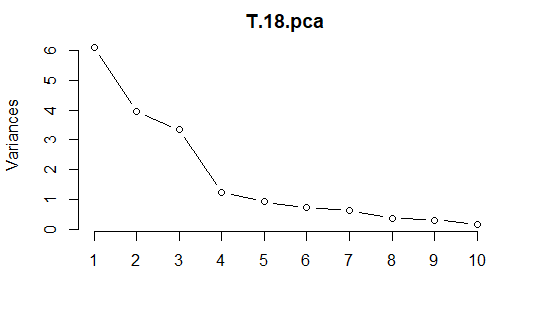

```r
T.18.pca <- prcomp(T.18, center = TRUE, scale. = TRUE)
screeplot(T.18.pca, type="lines")
```

The most obvious change in slope in the scree plot occurs at component 4, which is the “elbow” of the scree plot. Therefore, it cound be argued based on the basis of the scree plot that the first three components should be retained.

Another way of deciding how many components to retain is to use Kaiser’s criterion: that we should only retain principal components for which the variance is above 1 (when principal component analysis was applied to standardised data). We can check this by finding the variance of each of the principal components:

```r
(T.18.pca$sdev)^2
```

```
 [1] 6.102590e+00 3.946418e+00 3.339795e+00 1.232273e+00 9.323371e-01
 [6] 7.314076e-01 6.372587e-01 3.753322e-01 3.178664e-01 1.847776e-01
[11] 7.417828e-02 6.980869e-02 3.720730e-02 1.241689e-02 3.706036e-03
[16] 2.339936e-03 2.868659e-04 1.028193e-32
```

We see that the variance is above 1 for principal components 1, 2, 3 and 4 (which have variances 6.10, 3.95, 3.34, and 1.23 respectively). Therefore, using Kaiser’s criterion, we would retain the first four principal components.

A third way to decide how many principal components to retain is to decide to keep the number of components required to explain at least some minimum amount of the total variance. For example, if it is important to explain at least 80% of the variance, we would retain the first four principal components, as we can see from the output of `summary(T.18.pca)` that the first four principal components explain 81.2% of the variance (while the first three components explain just 74.4%, so are not sufficient).

```r
summary(T.18.pca)
```

```
Importance of components:
                         PC1    PC2    PC3     PC4    PC5     PC6    PC7     PC8
Standard deviation     2.470 1.9866 1.8275 1.11008 0.9656 0.85522 0.7983 0.61264
Proportion of Variance 0.339 0.2192 0.1855 0.06846 0.0518 0.04063 0.0354 0.02085
Cumulative Proportion  0.339 0.5583 0.7438 0.81228 0.8641 0.90471 0.9401 0.96097
                           PC9    PC10    PC11    PC12    PC13    PC14    PC15
Standard deviation     0.56380 0.42986 0.27236 0.26421 0.19289 0.11143 0.06088
Proportion of Variance 0.01766 0.01027 0.00412 0.00388 0.00207 0.00069 0.00021
Cumulative Proportion  0.97863 0.98889 0.99301 0.99689 0.99896 0.99965 0.99985
                          PC16    PC17      PC18
Standard deviation     0.04837 0.01694 1.014e-16
Proportion of Variance 0.00013 0.00002 0.000e+00
Cumulative Proportion  0.99998 1.00000 1.000e+00
```

### Interpreting the Results

Now, we can group our variables and see whether groups occupy a similar space in PCA space, indicating that they are correlated with each other. We do this using the groups argument in ggbiplot

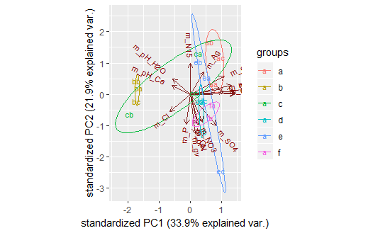

```r
#creating groups, turning ellipses on
T.18.pca <- prcomp(T.18, center = TRUE, scale. = TRUE)
site.groups <- c(rep("a", 3), rep("b", 3),rep("c", 3),rep("d", 3),rep("e", 3),rep("f", 3))
ggbiplot(T.18.pca, labels=rownames(T.18), groups = site.groups, ellipse = TRUE)
```

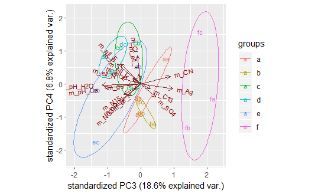

```r
#looking at the other PCA axes
ggbiplot(T.18.pca, labels=rownames(T.18), groups = site.groups, ellipse = TRUE, choices = c(3,4))
```

illustrates that axis three is useful for pulling out groups, such as f, so should include the first three axes as they contain alot of variation.

### Graphical parameters with ggbiplot

Are also othe variables that can be used to alter the biplots. * Can add a circle to the centre of the dataset * Can scale the sampples (obs.scale) and the variables (var.scale) * Can remove the arrows altogether using var.axes

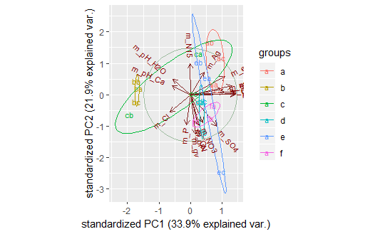

```r
T.18.pca <- prcomp(T.18, center = TRUE, scale. = TRUE)
ggbiplot(T.18.pca, labels=rownames(T.18), groups = site.groups, ellipse = TRUE, circle = TRUE)
```

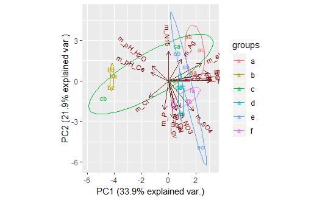

```r
ggbiplot(T.18.pca, labels=rownames(T.18), groups = site.groups, ellipse = TRUE, obs.scale = 1, var.scale = 1)
```

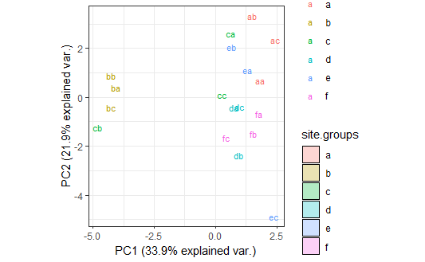

```r
ggbiplot(T.18.pca, labels=rownames(T.18), groups = site.groups, obs.scale = 1, var.scale = 1, var.axes=FALSE ) +
  theme_bw() +
  geom_mark_hull(concavity = 5, expand = 0, radius = 0, aes(fill=site.groups))
```

As ggbiplot is based on the ggplot function, you can use the same set of graphical parameters to alter the biplots as you would for any ggplot.

- Specify colours to use for the groups with `scale_colour_manual()`
- Add a title with `ggtitle()`
- Specify the `minimal()` theme, or other themes
- Move the legend with `theme()`

### Multivariate Packages

So far I been using the base `stats` package for conducting PCA. But there are other packagaes out there that are design to facilitate a suite of multivariate analysis. `ade4` is such a package.

Using the package `ade4` for multivariate analysis rather than base stats package. Combining with scree plots and comparing the `ade4` plotting functions to customised plotting using `ggplot` universe of packages

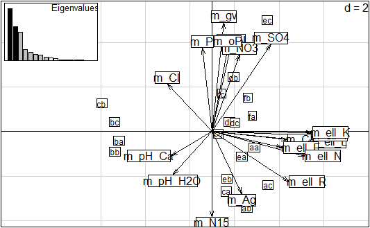

```r
library(ade4) # multivariate analysis
T.18.pca <- dudi.pca(T.18, scannf = F, nf = 8)

#The $co is the coordinates of variables in PCA space. Equivalent to loadings*sdev as calculated in theory section above for prcomp.
#The $li correspond to the individual, or row, cooridinates
scatter(T.18.pca)
```

Setting up libraries, and basic plot themes

```r
library(grid) # has the viewport function, needed for insetting the scree plot
library(ggpubr) #for making publication ready plots
library(ggforce) #for some nice polygons geoms
library(ggalt) #contains some extra geoms
library(viridis) #some nice colour palettes
library(hrbrthemes) #some nice themes for ggplot

### set up a plot we'll use later
ppp <- ggplot() +
  coord_fixed() +
  labs(x= paste("PCA 1 " , "(", round((T.18.pca$eig[1] / sum(T.18.pca$eig))*100, 1), "% explained var" , ")", sep = ""),
       y= paste("PCA 2 " , "(", round((T.18.pca$eig[2] / sum(T.18.pca$eig))*100, 1), "% explained var" , ")", sep = "")) +

  geom_hline(yintercept=0, col="darkgrey") +

  geom_vline(xintercept=0, col="darkgrey") +

  guides(size=guide_legend(title="PCA 3 (18.6%)")) +

  geom_segment(data =T.18.pca$co,
               x=0, y=0,
               xend = 2.5*T.18.pca$co[,1], yend = 2.5*T.18.pca$co[,2],
               arrow =  arrow(angle = 30,length = unit(0.25, "cm"),
                              ends = "last", type = "open"),
               alpha=0.4) +
  scale_color_viridis(discrete=TRUE, guide=FALSE) +
    theme_ipsum()

# make the scree plot in a viewport
myscree <- function(eigs, x=0.8, y=0.1, just=c("left","centre")){
  vp <- viewport(x=x, y=y, width=0.2, height=0.2, just=just)
  data <- as.data.frame(cbind(factor(1:length(eigs)), eigs))
  sp <- ggplot() +
    geom_col(aes(x=V1, y=eigs), data = data, position = "stack") +
    labs(x = NULL, y = NULL, title = "Scree Plot") +
    theme(title = element_text(size = 6))
  print(sp, vp=vp)
}
```

Plotting using `geom_mark_ellipse()` function in the `ggforce` package

```r
#set grouping factor for colour, grouping by sites and adding to dataframe
T.18.pca$li[,1+dim(T.18.pca$li)[2]]=site.groups

#creating a named logical vector for what legends to display. Want the size legend but not sites.
leg <- as.logical(c(1,0))
names(leg) <- c("size", "col")

ppp +
  geom_point(data=T.18.pca$li,
             aes(x=Axis1,
                 y=Axis2,
                 size=Axis3,
                 col=T.18.pca$li[,dim(T.18.pca$li)[2]]),
             show.legend = leg) +

   scale_color_viridis(discrete=TRUE, guide=FALSE) +

  guides(size=guide_legend(title="PCA 3 (18.6%)")) +

  geom_text(data=T.18.pca$co,
            aes(x=2.5*Comp1,
                y=2.5*Comp2,
                label=(colnames(T.18))),
            size = 2, alpha=0.4) +

  geom_mark_ellipse(data =T.18.pca$li, aes(x=Axis1, y=Axis2,
                                           group=T.18.pca$li[,dim(T.18.pca$li)[2]],
                                           fill=T.18.pca$li[,dim(T.18.pca$li)[2]]),
                    alpha=0.4, expand=0) +

  scale_fill_viridis(discrete=TRUE, guide=FALSE) +

  guides(fill=guide_legend(title="Sites"))
```

[output not shown]

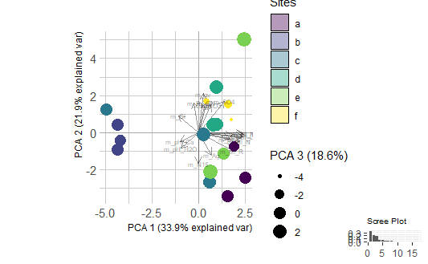

```r
myscree(T.18.pca$eig / sum(T.18.pca$eig))
```

```r
#can place labels whereever on the plot with this function, but it doesn't stay relative when size of plotting device changes
#grid.text(label = "text", x=0.83, y=0.75, rot=270, gp=gpar(fontsize=8, col="black"))
```

Plotting using `geom_encircle()` function in the `ggalt` package

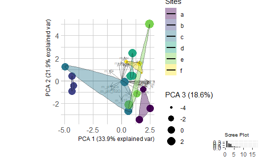

```r
ppp +
  geom_point(data=T.18.pca$li,
             aes(x=Axis1,
                 y=Axis2,
                 size=Axis3,
                 col=T.18.pca$li[,dim(T.18.pca$li)[2]]),
             show.legend = leg) +

  guides(size=guide_legend(title="PCA 3 (18.6%)")) +

  geom_text(data=T.18.pca$co,
            aes(x=2.5*Comp1,
                y=2.5*Comp2,
                label=(colnames(T.18))),
            size = 2, alpha=0.4) +

  geom_encircle(data =T.18.pca$li, aes(x=Axis1, y=Axis2,
                                           group=T.18.pca$li[,dim(T.18.pca$li)[2]],
                                           fill=T.18.pca$li[,dim(T.18.pca$li)[2]]),
                    alpha=0.4, expand=0) +

  scale_fill_viridis(discrete=TRUE, guide=FALSE) +

  guides(fill=guide_legend(title="Sites"))

myscree(T.18.pca$eig / sum(T.18.pca$eig))
```

### Predicting using PCA

see [here](http://www.sthda.com/english/articles/31-principal-component-methods-in-r-practical-guide/118-principal-component-analysis-in-r-prcomp-vs-princomp/)